# sts_campaign

## Safe to Sleep via D'EVA Consulting

The goal of this project was to complete network analyses from an Excel data file with regards to NICHD and six parter organizations. This project was completed in three days under a narrow deadline. A lot of the code is rushed and unpolished, but ultimately provides an example of network analysis for real work in a short timeframe.  
Steps for the project:

1. Wrote code to ingest and parse Excel file
2. Reviewed supporting material to understand the data, the organization, and the goals of the network analysis
3. Created visualizations for each of the categories provided in the Excel file
4. Added a write up that explained the approach, observations, and implications for future research.

!pip install xlrd

```python
import matplotlib.pyplot as plt
import pandas as pd
import networkx as nx
import seaborn as sns
from networkx.algorithms.approximation import clique
from networkx.algorithms.clique import find_cliques
from networkx.algorithms.centrality import degree_centrality
from networkx.algorithms.cluster import clustering
from networkx.algorithms.cluster import average_clustering
pd.set_option('display.max_colwidth', -1)
pd.set_option('display.max_rows', None)
```

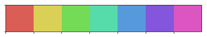

```python
orgs = ['AAP','ACOG','CDC','CPSC','First Candle','HRSA','NICHD']
colors = sns.color_palette("hls", 7)
sns.palplot(sns.color_palette("hls", 7))
```

```python
def lighten(colr, deg=.37):
    colr = tuple([c+deg for c in colr])
    return tuple([c if c<=1 else 1 for c in colr])

def darken(colr,deg=.37):
    colr = tuple([c-deg for c in colr])
    return tuple([c if c>=0 else 0 for c in colr])
```

```python
sts_logo = '\n'+r'Safe to Sleep$^®$ Campaign:'+'\n'
```

```python
def remove_str(s):
    if 'Safe Kids' in s:
        return 'Safe Kids'

    if 'Digital Media' in s:
        return 'Digital media'

    for o in orgs:
        if o in s:
            return o
    remove_l = ['• ','*']
    if 'Internal groups and committees focused on high-risk communities' in s:
        return 'Internal groups for high-risk'
    if '.org' in s:
        return 'Websites'
    if 'SUID/SIDS Project' in s:
        return 'SUID/SIDS Project'
    if 'National Fetal and Infant' in s:
        return 'NFIMR'
    if 'American Board of Obs' in s:
        return 'ABOG'
    if 'State and local' in s:
        return 'State/local health agencies'
    if 'National Center for Fatality' in s:
        return 'NCRFP'
    if 'Organizations that work with' in s:
        return 'Organizations that work with families'
    if 'State health offices and public health professionals' in s:
        return 'State health offices'
    if '(' in s:
        s = s.split(' (')[0]
    for r in remove_l:
        s = s.replace(r,'')
    if s[-1] == ' ':
        s = s[:-1]
    if s[0] == ' ':
        s = s[1:]
    if 'Grantees' in s:
        return 'Grantees'
    if s == 'Website' or s == 'website':
        return 'Websites'

    # techinical corrections
    if 'NAPPS-' in s:
        return 'NAPPSS-IIN'
    return s



def clean_data(cell):
    try:
        return [remove_str(i) for i in cell.split('\n') if len(i) >0 ]
    except AttributeError as e:
        return ['None']

excel_path = "net_an/NICHD_STS.xlsx"
sleep_df = pd.read_excel(excel_path)
sleep_df.columns = ['Category'] + [i for i in sleep_df.columns[1:]]
sleep_df = sleep_df.drop(sleep_df.index[-2:])
for c in sleep_df.columns:
    if c != 'Category':
        sleep_df[c] = sleep_df[c].apply(clean_data)
```

### Adjacency Matrix

```python
def create_adjacency_matrix(vals, filename):
    # create adjacency.txt for easy networkx import
    with open(f'{filename}.txt','w') as file:
        for l in vals:
            if len(l) > 1:
                file.write('|'.join(l)+'\n')

    return nx.read_adjlist(f'{file_name}.txt',delimiter='|')
```

## Partners

### Colors

#### Nodes

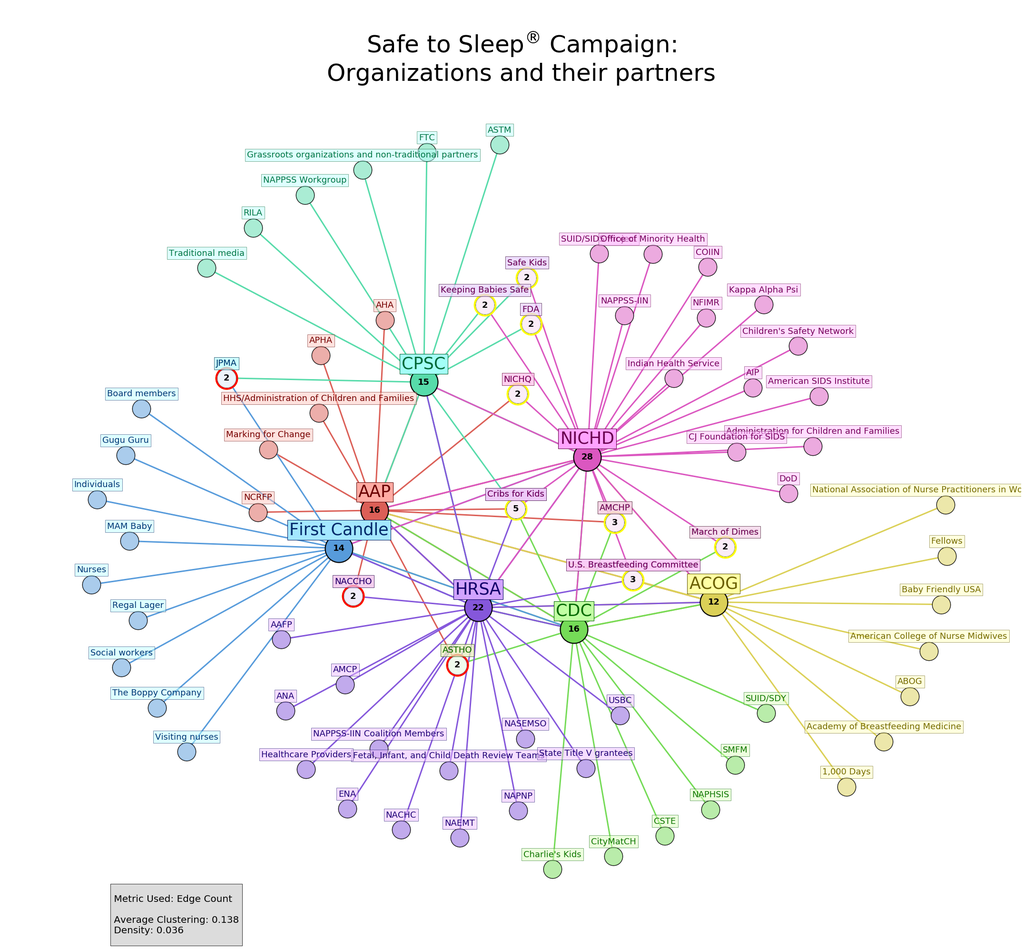

```python
# create the adj_matrix list
col_org_list = list(zip(list(range(1,8)),orgs))
big_m =[]
for i,org in col_org_list:
    for val in sleep_df.iloc[5].values[i]:
        small_m = [org,val]
        big_m.append(small_m)

file_name ='partners_edgecount'
G = create_adjacency_matrix(big_m,file_name)

G = nx.DiGraph(G)
main_nodes = [i for i in G.nodes if i in big_m[-1]]
main_nodes.append('NICHD')


node_count = {}
special_nodes = []
for val in list(G.nodes):
    n = len(G.edges(val))
    if n < 10 and n>1:
        special_nodes.append(val)
    if n == 1:
        n = ''
    node_count[val] = n

# Begin Visualization
fig = plt.figure(figsize=(30,28))
plt.title(f'{sts_logo}Organizations and their partners',size=15,color='black',fontsize=50)

pos = nx.kamada_kawai_layout(G)
pos['AAP'] = [pos['AAP'][0]-.2,pos['AAP'][1]]
pos['HRSA'] = [pos['HRSA'][0],pos['AAP'][1]-.25]



for i in range(1,8):
    edges=G.edges(orgs[i-1])
    nx.draw_networkx_edges(G,pos=pos,
                           style='dashed',
                           width=3,
                           arrow=False,
                           edgelist=edges,
                           edge_color=[colors[i-1] for n in edges],
                           alpha=.8)



nx.draw_networkx_nodes(G,pos,nodelist=special_nodes,node_color='yellow',node_size=2200,alpha=1)
investigate_nodes = ['ASTHO','JPMA','NACCHO']
nx.draw_networkx_nodes(G,pos,nodelist=investigate_nodes,node_color='red',node_size=2200,alpha=1)

for i in range(1,8):
    nx.draw_networkx_nodes(G,pos,nodelist=sleep_df.iloc[5].values[i],node_color='black',node_size=1500,alpha=1)
    nx.draw_networkx_nodes(G,pos,nodelist=sleep_df.iloc[5].values[i],node_color='white',node_size=1300,alpha=1)
    nx.draw_networkx_nodes(G,pos,nodelist=sleep_df.iloc[5].values[i],node_color=[colors[i-1]],node_size=1300,alpha=.5)

nx.draw_networkx_nodes(G,pos,nodelist=special_nodes,node_color='white',node_size=1500,alpha=.8)

for i in range(1,8):
    nx.draw_networkx_nodes(G,pos,nodelist=[orgs[i-1]],node_color='black',node_size=3500,alpha=1)
    nx.draw_networkx_nodes(G,pos,nodelist=[orgs[i-1]],node_color=[colors[i-1]],node_size=3000,alpha=1)


nx.draw_networkx_labels(G,pos=pos,font_size=18,labels=node_count,font_weight='bold',font_color='black')

# clustering_labels = clustering(G)
# for k in list(clustering_labels.keys()):
#     clustering_labels[k] = round(clustering_labels[k], 3)
# nx.draw_networkx_labels(G,pos=pos,font_size=18,labels=clustering_labels,font_weight='bold',font_color='black')



for k in pos:
    pos[k] = [pos[k][0],pos[k][1]+.038]

for i in range(1,8):
    org_labels = {}
    for val in sleep_df.iloc[5].values[i]:
        org_labels[val] = val
    nx.draw_networkx_labels(G,
                            pos=pos,
                            font_size=18,
                            labels=org_labels,
                            font_color=darken(colors[i-1],.4),
                            bbox=dict(facecolor=lighten(colors[i-1],.4),
                                      alpha=.5,
                                      edgecolor=darken(colors[i-1],.5)))

for k in pos:
    pos[k] = [pos[k][0],pos[k][1]+.009]

for i in range(1,8):
    org_labels = {}
    org_labels[orgs[i-1]] = orgs[i-1]
    nx.draw_networkx_labels(G,pos=pos,font_size=35,labels=org_labels,font_color=darken(colors[i-1],.45),bbox=dict(facecolor=lighten(colors[i-1],.3),alpha=1,edgecolor=darken(colors[i-1],.5)))

plt.annotate(
s = f"\n Metric Used: Edge Count \n\n Average Clustering: {round(average_clustering(G),3)} \n Density: {round(nx.density(G),3)} \n",
xy=(-.9, -.9),
va='top',
ha='left',
fontsize = 20,
bbox=dict(facecolor='lightgray', alpha=.8,pad=.5,),
)

plt.axis('off')
plt.tight_layout()
plt.savefig(f'final_visual/{file_name}.png',dpi=300)
plt.show()
```

#### Clustering Coefficient

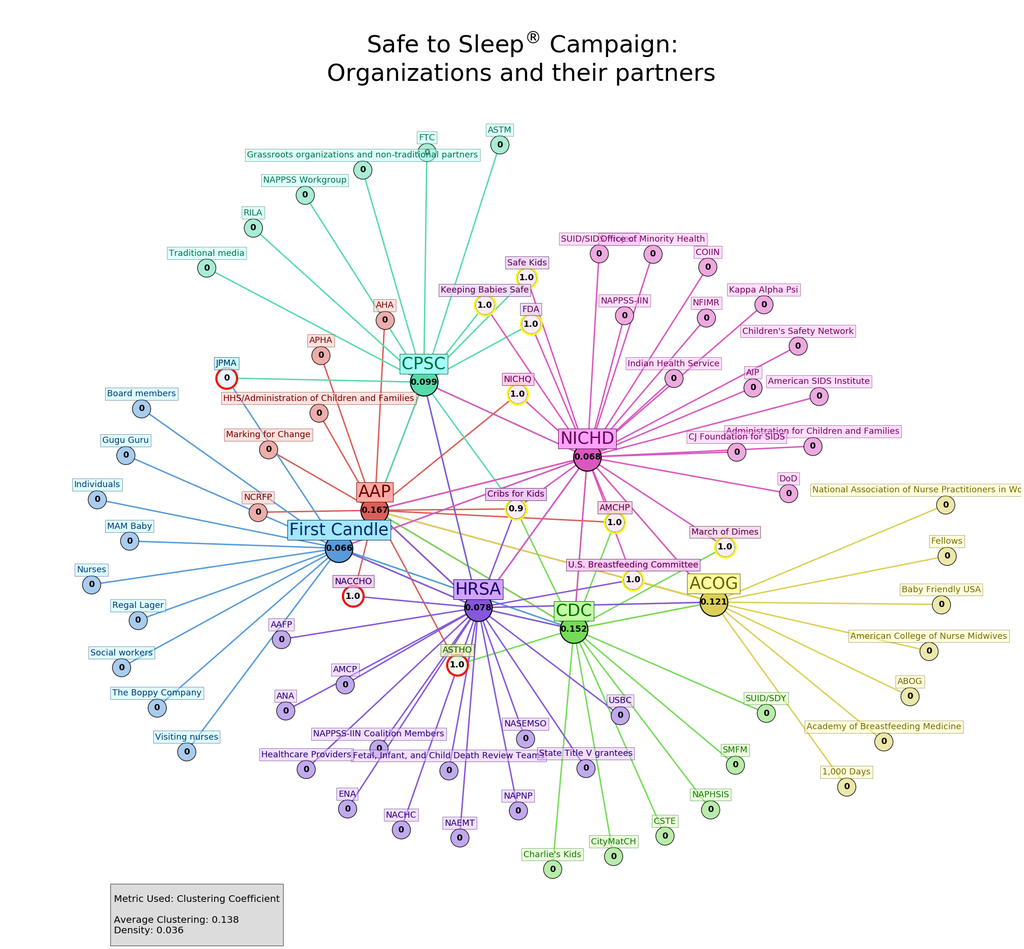

```python
# create the adj_matrix list
col_org_list = list(zip(list(range(1,8)),orgs))
big_m =[]
for i,org in col_org_list:
    for val in sleep_df.iloc[5].values[i]:
        small_m = [org,val]
        big_m.append(small_m)

file_name ='partners_clusteringcoef'
G = create_adjacency_matrix(big_m,file_name)

G = nx.DiGraph(G)
main_nodes = [i for i in G.nodes if i in big_m[-1]]
main_nodes.append('NICHD')

node_count = {}
special_nodes = []
for val in list(G.nodes):
    n = len(G.edges(val))
    if n < 10 and n>1:
        special_nodes.append(val)
    if n == 1:
        n = ''
    node_count[val] = n

# Begin Visualization
fig = plt.figure(figsize=(30,28))
plt.title(f'{sts_logo}Organizations and their partners',size=15,color='black',fontsize=50)

pos = nx.kamada_kawai_layout(G)
pos['AAP'] = [pos['AAP'][0]-.2,pos['AAP'][1]]
pos['HRSA'] = [pos['HRSA'][0],pos['AAP'][1]-.25]



for i in range(1,8):
    edges=G.edges(orgs[i-1])
    nx.draw_networkx_edges(G,pos=pos,
                           style='dashed',
                           width=3,
                           arrow=False,
                           edgelist=edges,
                           edge_color=[colors[i-1] for n in edges],
                           alpha=.8)



nx.draw_networkx_nodes(G,pos,nodelist=special_nodes,node_color='yellow',node_size=2200,alpha=1)
investigate_nodes = ['ASTHO','JPMA','NACCHO']
nx.draw_networkx_nodes(G,pos,nodelist=investigate_nodes,node_color='red',node_size=2200,alpha=1)

for i in range(1,8):
    nx.draw_networkx_nodes(G,pos,nodelist=sleep_df.iloc[5].values[i],node_color='black',node_size=1500,alpha=1)
    nx.draw_networkx_nodes(G,pos,nodelist=sleep_df.iloc[5].values[i],node_color='white',node_size=1300,alpha=1)
    nx.draw_networkx_nodes(G,pos,nodelist=sleep_df.iloc[5].values[i],node_color=[colors[i-1]],node_size=1300,alpha=.5)

nx.draw_networkx_nodes(G,pos,nodelist=special_nodes,node_color='white',node_size=1500,alpha=.8)

for i in range(1,8):
    nx.draw_networkx_nodes(G,pos,nodelist=[orgs[i-1]],node_color='black',node_size=3500,alpha=1)
    nx.draw_networkx_nodes(G,pos,nodelist=[orgs[i-1]],node_color=[colors[i-1]],node_size=3000,alpha=1)


# nx.draw_networkx_labels(G,pos=pos,font_size=18,labels=node_count,font_weight='bold',font_color='black')

clustering_labels = clustering(G)
for k in list(clustering_labels.keys()):
    clustering_labels[k] = round(clustering_labels[k], 3)
nx.draw_networkx_labels(G,pos=pos,font_size=18,labels=clustering_labels,font_weight='bold',font_color='black')



for k in pos:
    pos[k] = [pos[k][0],pos[k][1]+.038]

for i in range(1,8):
    org_labels = {}
    for val in sleep_df.iloc[5].values[i]:
        org_labels[val] = val
    nx.draw_networkx_labels(G,
                            pos=pos,
                            font_size=18,
                            labels=org_labels,
                            font_color=darken(colors[i-1],.4),
                            bbox=dict(facecolor=lighten(colors[i-1],.4),
                                      alpha=.5,
                                      edgecolor=darken(colors[i-1],.5)))

for k in pos:
    pos[k] = [pos[k][0],pos[k][1]+.009]

for i in range(1,8):
    org_labels = {}
    org_labels[orgs[i-1]] = orgs[i-1]
    nx.draw_networkx_labels(G,pos=pos,font_size=35,labels=org_labels,font_color=darken(colors[i-1],.45),bbox=dict(facecolor=lighten(colors[i-1],.3),alpha=1,edgecolor=darken(colors[i-1],.5)))

plt.annotate(
s = f"\n Metric Used: Clustering Coefficient \n\n Average Clustering: {round(average_clustering(G),3)} \n Density: {round(nx.density(G),3)} \n",
xy=(-.9, -.9),
va='top',
ha='left',
fontsize = 20,
bbox=dict(facecolor='lightgray', alpha=.8,pad=.5,),
)


plt.axis('off')
plt.tight_layout()
plt.savefig(f'final_visual/{file_name}.png')
plt.show()
```